# compare_face_detection_efficacy

## Case Study - Comparing Efficacy for Real-Time Face Detection Models

A crucial factor for success when it comes to real-time face detection system is efficacy. In this case study, we compare different methods for face detection and compare their efficacy. The methods are:

- Hog
- Haar
- DNN

Run the following code block to setup imports:

```python
# Importing packages for CV2, DLIB and Plotting
import cv2
import dlib
import matplotlib.pyplot as pyplot

# For benchmarking the process of generating the graph
import time

# For iterating over a folder
import os

# For creating the progress bar when looping over the dataset
from tqdm.notebook import tqdm

# For profiling memory usage
from memory_profiler import memory_usage
```

### 1. Code snippets for each model

The following code are the function for each face detection model. The code for the individual models can be found in within `src/models/code/` the `OpenCV_Server` repository. Each file has a function that is called on a single frame. The output is either a list of boundary boxes (`Rect`) or `None`. The functions are moved over to this file for the sake of simplicity.

Run them to save the functions:

```python
# Haar Cascade
def detect_face_haar(img,detectMultipleFaces=True, scale=1.1, neighbors=10, size=50):
    """Detect a face in an image using a pre-trained Haar Cascade model.

    The model has been trained by OpenCV.
    See: https://opencv.org/

    Args:
        img (numpy.ndarray):
            Image read from the cv2.imread function. Ut is a numpy
        detectMultipleFaces (boolean):
            Toggle for returning more than one face detected. Default is false.
        scale (float, optional):
            For scaling down the input image, before trying to detect a face. Makes it easier to detect a face with smaller scale. Defaults to 1.1.
        neighbors (int, optional):
            Amount of neighbor rectangles needed for a face to be set as detected. Defaults to 10.
        size (int, optional):
            Size of the sliding window that checks for any facial features. Should match the face size in the image, that should be detected. Defaults to 50.

    Returns:
        Rect: Datatype of a rectangle, that overlays the position of the detected face. It has four attributes of intrests: x-position, y-position,
    """

    # Turing the image into a grayscale image
    gray_image = cv2.cvtColor(img, cv2.COLOR_BGR2GRAY)

    # Printing the gray scale image
    # print(f"Gray-Scale Image dimension: ({gray_image.shape})")

    # Loading the classifier from a pretrained dataset
    face_classifier = cv2.CascadeClassifier(
        cv2.data.haarcascades + "haarcascade_frontalface_default.xml"
    )

    # Performing the face detection
    faces = face_classifier.detectMultiScale(
        gray_image, scaleFactor=scale, minNeighbors=neighbors, minSize=(size,size)
    )

    # Return amount of
    if detectMultipleFaces == True:
        return faces
    return faces[0] if faces else None


# HOG
def detect_face_hog(img,detectMultipleFaces=True):
    # Turing the image into a grayscale image
    gray_image = cv2.cvtColor(img, cv2.COLOR_BGR2GRAY)

    # Define the HOG detector from dlib
    hog_face_detector = dlib.get_frontal_face_detector()

    # Detect faces from the grayscale image
    faces = hog_face_detector(gray_image, 1)

    # Check if only one face is needed
    if detectMultipleFaces == True:
        return faces
    return faces[0] if faces else None


# DNN
def detect_face_dnn(img, net, framework="caffe", conf_threshold=0.7, detectMultipleFaces=True):
    """
    Detect faces in an image using a deep neural network (DNN).

    Parameters:
    - img: The input image.
    - net: The pre-trained DNN model for face detection.
    - framework: The framework used for the DNN model ("caffe" or "tensorflow").
    - conf_threshold: The confidence threshold for detecting faces.
    - detect_multiple_faces: Boolean flag to detect multiple faces or just the first one.

    Returns:
    - A list of bounding boxes for detected faces or a single bounding box if detectMultipleFaces is False.
    """
    frameHeight = img.shape[0]
    frameWidth = img.shape[1]
    if framework == "caffe":
        blob = cv2.dnn.blobFromImage(img, 1.0, (300, 300), [104, 117, 123], False, False)
    else:
        blob = cv2.dnn.blobFromImage(img, 1.0, (300, 300), [104, 117, 123], True, False)

    net.setInput(blob)
    detections = net.forward()
    bboxes = []
    for i in range(detections.shape[2]):
        confidence = detections[0, 0, i, 2]
        if confidence > conf_threshold:
            x1 = int(detections[0, 0, i, 3] * frameWidth)
            y1 = int(detections[0, 0, i, 4] * frameHeight)
            x2 = int(detections[0, 0, i, 5] * frameWidth)
            y2 = int(detections[0, 0, i, 6] * frameHeight)
            width = x2 - x1
            height = y2 - y1
            bboxes.append((x1, y1, width, height))

    if detectMultipleFaces == True:
        return bboxes
    return bboxes[0] if bboxes else None
```

### 2. The DataSet

```python
# TODO: TEST THAT DATASET CAN BE LOADED IN

# Path to videos
video_path = "../data/test_data/videos/"
```

### 3. Metrics

This case study is going to measure two things:

- FPS
- Memory usage

**Why FPS?** Because it measures the amount of frames processed by each model. The other metric is Memory usage.  
**Why Memory Usage?** Because we want to see how memory heavy the algorithms are

### 4. Measuring FPS

Run the following code block to measure FPS over the dataset:

```python
# Lists to store FPS stats for each video
average_fps_per_video_haar = []
average_fps_per_video_hog = []
average_fps_per_video_dnn = []

# Initialize the progress bar for both videos processed
progress_bar_videos = tqdm(total=len(os.listdir(video_path)), desc="Videos Processed")

# Setting up for the DNN face detection method
modelFile = "../src/models/trained_models/res10_300x300_ssd_iter_140000_fp16.caffemodel"
configFile = "../src/models/trained_models/deploy.prototxt"
net = cv2.dnn.readNetFromCaffe(configFile, modelFile)


# For each video in the folder, open them
for video in os.listdir(video_path):
    # Check if the file is a video
    if not video.endswith(".mp4"):
        print("[ERROR] Only MP4 videos are allowed")
        break

    # Full video path
    path = os.path.join(video_path, video)

    # Open the video
    cap = cv2.VideoCapture(path)

    total_frames = int(cap.get(cv2.CAP_PROP_FRAME_COUNT))
    progress_bar_frames_description = "Frame processed in " + video
    progress_bar_frames = tqdm(total=total_frames, desc=progress_bar_frames_description)


    # Temporary lists to store FPS for the current video
    fps_current_video_haar = []
    fps_current_video_hog = []
    fps_current_video_dnn = []

    while True:
        # Read frame
        ret, frame = cap.read()

        # If frame is read correctly, ret is True
        if not ret:
            print(f"[ERROR] Could not read the mp4 file: {video}")
            break

        # Process the frame with Haar
        start_time = time.time()
        _ = detect_face_haar(frame, detectMultipleFaces=True)
        end_time = time.time()
        fps_current_video_haar.append(1 / (end_time - start_time))

        # Process the frame with HOG
        start_time = time.time()
        _ = detect_face_hog(frame, detectMultipleFaces=True)
        end_time = time.time()
        fps_current_video_hog.append(1 / (end_time - start_time))

        # Process the frame with DNN
        start_time = time.time()
        _ = detect_face_dnn(frame, net, framework="caffe", conf_threshold=0.89, detectMultipleFaces=True)
        end_time = time.time()
        fps_current_video_dnn.append(1 / (end_time - start_time))

        # Update the process bar for frame processed
        progress_bar_frames.update(1)

    # Close the cap and stop the progress bar
    progress_bar_frames.close()
    cap.release()

    # Calculate and store the average FPS for the current video for each method
    average_fps_per_video_haar.append(sum(fps_current_video_haar) / len(fps_current_video_haar))
    average_fps_per_video_hog.append(sum(fps_current_video_hog) / len(fps_current_video_hog))
    average_fps_per_video_dnn.append(sum(fps_current_video_dnn) / len(fps_current_video_dnn))


    # Update the progress bar
    progress_bar_videos.update(1)

# Stop the progress bar
progress_bar_videos.close()

# Example to calculate the average FPS
average_fps_haar = sum(average_fps_per_video_haar) / len(average_fps_per_video_haar)
average_fps_hog = sum(average_fps_per_video_hog) / len(average_fps_per_video_hog)
average_fps_dnn = sum(average_fps_per_video_dnn) / len(average_fps_per_video_dnn)
```

```
[ERROR] Could not read the mp4 file: head-pose-face-detection-female-and-male_12FPS.mp4
```

```
[ERROR] Could not read the mp4 file: head-pose-face-detection-male_12FPS.mp4
```

```
[ERROR] Could not read the mp4 file: head-pose-face-detection-female_12FPS.mp4
```

```
[ERROR] Could not read the mp4 file: face-demographics-walking-and-pause_12FPS.mp4
```

```
[ERROR] Could not read the mp4 file: classroom_30FPS.mp4
```

```
[ERROR] Could not read the mp4 file: face-demographics-walking_12FPS.mp4
```

Plotting the average FPS in graph. This first graph show the average FPS total

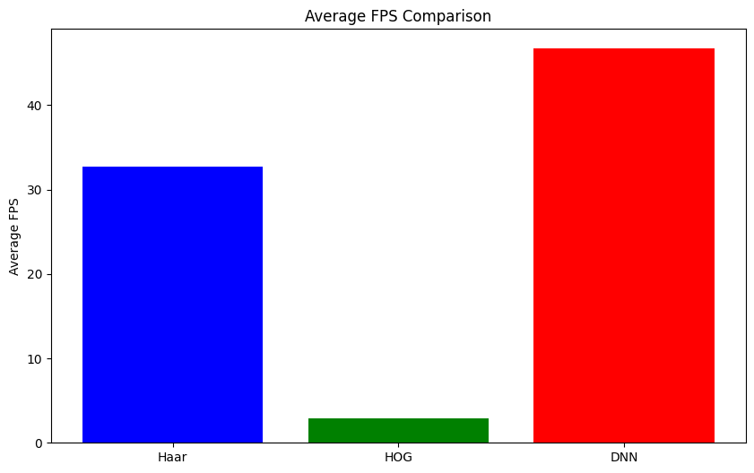

```python
# Method names
methods = ['Haar', 'HOG', 'DNN']

# Average FPS values
fps_values = [average_fps_haar, average_fps_hog, average_fps_dnn]

# Creating the bar chart
pyplot.figure(figsize=(10, 6))  # Set the figure size (optional)
pyplot.bar(methods, fps_values, color=['blue', 'green', 'red'])

# Adding title and labels
pyplot.title('Average FPS Comparison')
pyplot.ylabel('Average FPS')

# Saving the figure to a set path
pyplot.savefig("../data/results/compare_face_detection_fps.png")

# Displaying the chart
pyplot.show()
```

Plotting the average FPS for each video in a line graph. This will give a better understand of how each individual video impacted the FPS result:

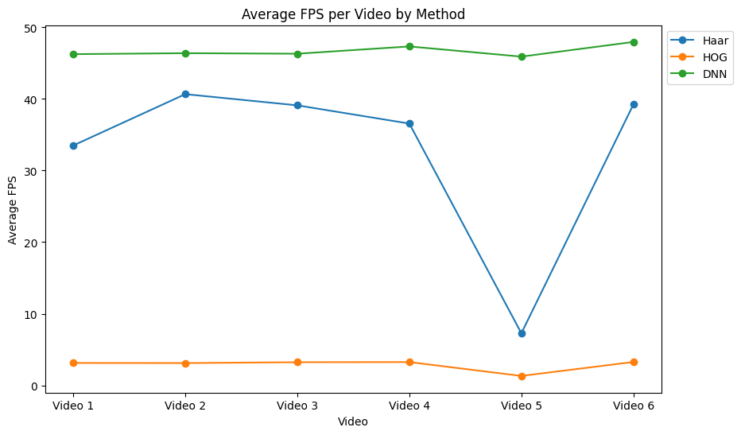

```python
# Determine how many videos was processed
number_of_videos = len(average_fps_per_video_haar)

# Adding the three methods into a
fps_data = {
    'Haar': average_fps_per_video_haar,  # Example data for 4 videos
    'HOG': average_fps_per_video_hog,   # Example data for 4 videos
    'DNN': average_fps_per_video_dnn,   # Example data for 4 videos
    # Additional methods can easily be added or removed here
}

# Generate video labels dynamically
videos = [f'Video {i+1}' for i in range(number_of_videos)]

# Plotting the line chart dynamically
pyplot.figure(figsize=(10, 6))

# Iterate over each method and its FPS data
for method, fps_values in fps_data.items():
    pyplot.plot(videos, fps_values, label=method, marker='o')

# Adding title and labels
pyplot.title('Average FPS per Video by Method')
pyplot.xlabel('Video')
pyplot.ylabel('Average FPS')

# Adding a legend
pyplot.legend(loc='upper left', bbox_to_anchor=(1, 1))

# Saving the figure to a set path
pyplot.savefig("../data/results/compare_face_detection_fps_per_video.png")

# Displaying the chart
pyplot.show()
```

### 5. Measuring Memory Usage

```python
# Lists to store memory usage stats for each video
average_memory_per_video_haar = []
average_memory_per_video_hog = []
average_memory_per_video_dnn = []

# Initialize the progress bar for videos processed
progress_bar_videos = tqdm(total=len(os.listdir(video_path)), desc="Videos Processed")

# Setup for the DNN face detection method
modelFile = "../src/models/trained_models/res10_300x300_ssd_iter_140000_fp16.caffemodel"
configFile = "../src/models/trained_models/deploy.prototxt"
net = cv2.dnn.readNetFromCaffe(configFile, modelFile)

# For each video in the folder
for video in os.listdir(video_path):
    if not video.endswith(".mp4"):
        print("[ERROR] Only MP4 videos are allowed")
        break

    path = os.path.join(video_path, video)
    cap = cv2.VideoCapture(path)

    total_frames = int(cap.get(cv2.CAP_PROP_FRAME_COUNT))
    progress_bar_frames_description = "Frame processed in " + video
    progress_bar_frames = tqdm(total=total_frames, desc=progress_bar_frames_description)

    # Temporary lists to store memory usage for the current video
    memory_usage_current_video_haar = []
    memory_usage_current_video_hog = []
    memory_usage_current_video_dnn = []

    while True:
        ret, frame = cap.read()
        if not ret:
            print(f"[ERROR] Could not read the mp4 file: {video}")
            break

        # Measure memory usage for Haar
        memory_usage_haar = memory_usage((detect_face_haar, (frame,)), max_usage=True)
        memory_usage_current_video_haar.append(memory_usage_haar)

        # Measure memory usage for HOG
        memory_usage_hog = memory_usage((detect_face_hog, (frame,)), max_usage=True)
        memory_usage_current_video_hog.append(memory_usage_hog)

        # Measure memory usage for DNN
        memory_usage_dnn = memory_usage((detect_face_dnn, (frame, net)), max_usage=True)
        memory_usage_current_video_dnn.append(memory_usage_dnn)

        progress_bar_frames.update(1)

    progress_bar_frames.close()
    cap.release()

    # Calculate and store the average memory usage for the current video for each method
    average_memory_per_video_haar.append(sum(memory_usage_current_video_haar) / len(memory_usage_current_video_haar))
    average_memory_per_video_hog.append(sum(memory_usage_current_video_hog) / len(memory_usage_current_video_hog))
    average_memory_per_video_dnn.append(sum(memory_usage_current_video_dnn) / len(memory_usage_current_video_dnn))

    progress_bar_videos.update(1)

progress_bar_videos.close()

# To calculate the average memory usage for each method across all videos
average_memory_haar = sum(average_memory_per_video_haar) / len(average_memory_per_video_haar)
average_memory_hog = sum(average_memory_per_video_hog) / len(average_memory_per_video_hog)
average_memory_dnn = sum(average_memory_per_video_dnn) / len(average_memory_per_video_dnn)

# Printing out the results
print(f"Average Memory Usage (Haar): {average_memory_haar} MB")
print(f"Average Memory Usage (HOG): {average_memory_hog} MB")
print(f"Average Memory Usage (DNN): {average_memory_dnn} MB")
```

```
[ERROR] Could not read the mp4 file: head-pose-face-detection-female-and-male_12FPS.mp4
```

```
[ERROR] Could not read the mp4 file: head-pose-face-detection-male_12FPS.mp4
```

```
[ERROR] Could not read the mp4 file: head-pose-face-detection-female_12FPS.mp4
```

```
[ERROR] Could not read the mp4 file: face-demographics-walking-and-pause_12FPS.mp4
```

```
[ERROR] Could not read the mp4 file: classroom_30FPS.mp4
```

```
[ERROR] Could not read the mp4 file: face-demographics-walking_12FPS.mp4
Average Memory Usage (Haar): 301.5709696487329 MB
Average Memory Usage (HOG): 307.0189262693996 MB
Average Memory Usage (DNN): 297.36347625004544 MB
```

Plotting the result in two graphs. First the a bar graph for the average memory per method:

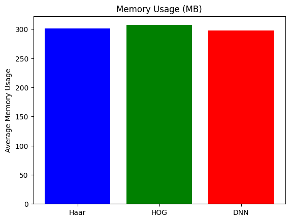

```python
# Method names
methods = ['Haar', 'HOG', 'DNN']

# Average FPS values
memory_values = [average_memory_haar, average_memory_hog, average_memory_dnn]

# Creating the bar chart
pyplot.bar(methods, memory_values, color=['blue', 'green', 'red'])

# Adding title and labels
pyplot.title('Memory Usage (MB)')
pyplot.ylabel('Average Memory Usage')

# Saving the figure to a set path
pyplot.savefig("../data/results/compare_face_detection_memory.png")

# Displaying the chart
pyplot.show()
```

This next graph shows memory usage for each video by each method:

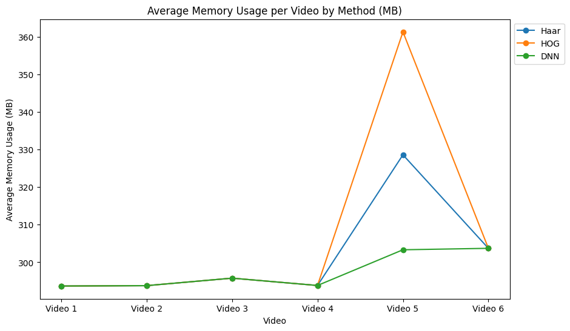

```python
# Determine how many videos was processed
number_of_videos = len(average_memory_per_video_hog)

# Adding the three methods into a
memory_data = {
    'Haar': average_memory_per_video_haar,
    'HOG': average_memory_per_video_hog,
    'DNN': average_memory_per_video_dnn,
}

# Generate video labels dynamically
videos = [f'Video {i+1}' for i in range(number_of_videos)]

# Plotting the line chart dynamically
pyplot.figure(figsize=(10, 6))

# Iterate over each method and its FPS data
for method, memory_values in memory_data.items():
    pyplot.plot(videos, memory_values, label=method, marker='o')

# Adding title and labels
pyplot.title('Average Memory Usage per Video by Method (MB)')
pyplot.xlabel('Video')
pyplot.ylabel('Average Memory Usage (MB)')

# Adding a legend
pyplot.legend(loc='upper left', bbox_to_anchor=(1, 1))

# Saving the figure to a set path
pyplot.savefig("../data/results/compare_face_detection_memory_per_video.png")

# Displaying the chart
pyplot.show()
```

### Resources

This section is the list of resources that was used to setup this case study. Both scientific articles and docs will be linked below:

What are FPS (Wikipedia article):  
https://en.wikipedia.org/wiki/Frame_rate

Memory Profiler Docs:  
https://pypi.org/project/memory-profiler/

YouTube Faces Database:  
https://www.cs.tau.ac.il/~wolf/ytfaces/

Matplotlib Docs (For creating the graphs):  
https://matplotlib.org/stable/index.html